# Rogerfederer_detector

### YOLO based AI detector for localizing Roger Federer, tennis racket and tennis ball in images

#### Author: Aditya Patel

`Goal`: I built an AI system which takes in an image and detects and localizes Roger Federer, tennis racket and ball (3 classes )in it and ignores all other objects in image

`MLOps Tools used`: I manually albeit laboriously hand annotated labels myself for each image using`Roboflow`  
`Algorithms` - `Yolov5s` weights  
`Why Yolo5`: I chose YOLO5 primarily because the algorithm automatically chooses anchor boxes to adjust to the labels. This is beyond amazing. This functionality is not available in Yolo2,Yolo3 & Yolo4 which makes customized anchor boxes a pain in the neck. Note that anchor boxes are, by default, geared towards detecting COCO objects because YOLO5 was trained on COCO. This makes hard to make customized anchor boxes of various sizes, shapes for racket, ball and Federer. Yolov5 eliminates that problem, so I used 5th version. Also Yolo5 is written in Python, not C++ and is built on top of Pytorch

`Dataset`: 48 images downloaded via google search.  
`Annotations`: Manually hand annotated labels myself in Roboflow. Roboflow converted it into Yolov5 Pytorch format.

The fact that my model did so well inspite of tiny images making object detection hard(just like human eye finds it hard to detect objects if image is tiny, same intuition applies for my AI model), inspite of just 17 images (real world datasets are trained on atleast 250 images of each type), indicates that there is lot of room for improvement. I am confident I can better this performance

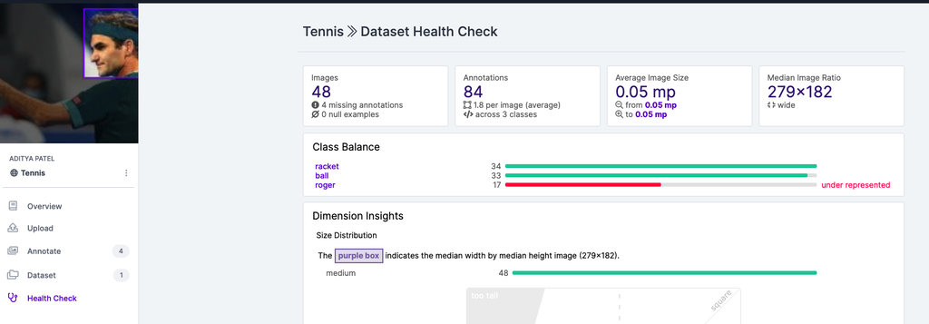

## Showing a Subset of training images I used downloaded from internet

[figure not shown]

```python
!git clone https://github.com/ultralytics/yolov5  # clone repo
%cd yolov5
%pip install -qr requirements.txt # install dependencies
%pip install -q roboflow

import torch
import os
from IPython.display import Image, clear_output  # to display images

print(f"Setup complete. Using torch {torch.__version__} ({torch.cuda.get_device_properties(0).name if torch.cuda.is_available() else 'CPU'})")
```

[output not shown]

```python
from roboflow import Roboflow
rf = Roboflow(model_format="yolov5", notebook="ultralytics")
```

```
upload and label your dataset, and get an API KEY here: https://app.roboflow.com/?model=yolov5&ref=ultralytics
```

```python
# set up colab environment
os.environ["DATASET_DIRECTORY"] = "/content/datasets"
```

```python
# Roboflow provided instructions
from roboflow import Roboflow
rf = Roboflow(api_key="secret")  # replaced actual key for privacy. Co
project = rf.workspace().project("tennis-tkslp")
dataset = project.version(1).download("yolov5")
```

```python
!python train.py --img 416 --batch 16 --epochs 200 --data {dataset.location}/data.yaml --weights yolov5s.pt --cache
```

```
Downloading https://ultralytics.com/assets/Arial.ttf to /root/.config/Ultralytics/Arial.ttf...
train: weights=yolov5s.pt, cfg=, data=/content/datasets/Tennis-1/data.yaml, hyp=data/hyps/hyp.scratch.yaml, epochs=200, batch_size=16, imgsz=416, rect=False, resume=False, nosave=False, noval=False, noautoanchor=False, evolve=None, bucket=, cache=ram, image_weights=False, device=, multi_scale=False,…
github: up to date with https://github.com/ultralytics/yolov5 ✅
YOLOv5 🚀 v6.0-104-g4ca4aec torch 1.10.0+cu111 CUDA:0 (Tesla K80, 11441MiB)

hyperparameters: lr0=0.01, lrf=0.1, momentum=0.937, weight_decay=0.0005, warmup_epochs=3.0, warmup_momentum=0.8, warmup_bias_lr=0.1, box=0.05, cls=0.5, cls_pw=1.0, obj=1.0, obj_pw=1.0, iou_t=0.2, anchor_t=4.0, fl_gamma=0.0, hsv_h=0.015, hsv_s=0.7, hsv_v=0.4, degrees=0.0, translate=0.1, scale=0.5, sh…
Weights & Biases: run 'pip install wandb' to automatically track and visualize YOLOv5 🚀 runs (RECOMMENDED)
TensorBoard: Start with 'tensorboard --logdir runs/train', view at http://localhost:6006/
Downloading https://github.com/ultralytics/yolov5/releases/download/v6.0/yolov5s.pt to yolov5s.pt...
100% 14.0M/14.0M [00:00<00:00, 61.9MB/s]

Overriding model.yaml nc=80 with nc=3

                 from  n    params  module                                  arguments
  0                -1  1      3520  models.common.Conv                      [3, 32, 6, 2, 2]
  1                -1  1     18560  models.common.Conv                      [32, 64, 3, 2]
  2                -1  1     18816  models.common.C3                        [64, 64, 1]
  3                -1  1     73984  models.common.Conv                      [64, 128, 3, 2]
  4                -1  2    115712  models.common.C3                        [128, 128, 2]
  5                -1  1    295424  models.common.Conv                      [128, 256, 3, 2]
  6                -1  3    625152  models.common.C3                        [256, 256, 3]
  7                -1  1   1180672  models.common.Conv                      [256, 512, 3, 2]
  8                -1  1   1182720  models.common.C3                        [512, 512, 1]
  9                -1  1    656896  models.common.SPPF                      [512, 512, 5]
 10                -1  1    131584  models.common.Conv                      [512, 256, 1, 1]
 11                -1  1         0  torch.nn.modules.upsampling.Upsample    [None, 2, 'nearest']
 12           [-1, 6]  1         0  models.common.Concat                    [1]
 13                -1  1    361984  models.common.C3                        [512, 256, 1, False]
 14                -1  1     33024  models.common.Conv                      [256, 128, 1, 1]
 15                -1  1         0  torch.nn.modules.upsampling.Upsample    [None, 2, 'nearest']
 16           [-1, 4]  1         0  models.common.Concat                    [1]
 17                -1  1     90880  models.common.C3                        [256, 128, 1, False]
 18                -1  1    147712  models.common.Conv                      [128, 128, 3, 2]
 19          [-1, 14]  1         0  models.common.Concat                    [1]
 20                -1  1    296448  models.common.C3                        [256, 256, 1, False]
 21                -1  1    590336  models.common.Conv                      [256, 256, 3, 2]
 22          [-1, 10]  1         0  models.common.Concat                    [1]
 23                -1  1   1182720  models.common.C3                        [512, 512, 1, False]
 24      [17, 20, 23]  1     21576  models.yolo.Detect                      [3, [[10, 13, 16, 30, 33, 23], [30, 61, 62, 45, 59, 119], [116, 90, 156, 198, 373, 326]], [128, 256, 512]]
Model Summary: 270 layers, 7027720 parameters, 7027720 gradients, 15.9 GFLOPs
```

[output cut: 1017 more lines]

```
                 all         10         13      0.599      0.598      0.627       0.28

200 epochs completed in 0.236 hours.
Optimizer stripped from runs/train/exp/weights/last.pt, 14.3MB
Optimizer stripped from runs/train/exp/weights/best.pt, 14.3MB

Validating runs/train/exp/weights/best.pt...
Fusing layers...
Model Summary: 213 layers, 7018216 parameters, 0 gradients, 15.8 GFLOPs
               Class     Images     Labels          P          R     mAP@.5 mAP@.5:.95: 100% 1/1 [00:00<00:00,  5.41it/s]
                 all         10         13      0.984      0.578      0.654      0.386
                ball         10          4          1      0.934      0.995      0.597
              racket         10          5      0.952        0.8      0.813      0.472
               roger         10          4          1          0      0.154     0.0894
Results saved to runs/train/exp
```

```python
# Start tensorboard
# Launch after you have started training
# logs save in the folder "runs"
%load_ext tensorboard
%tensorboard --logdir runs
```

[figure not shown]

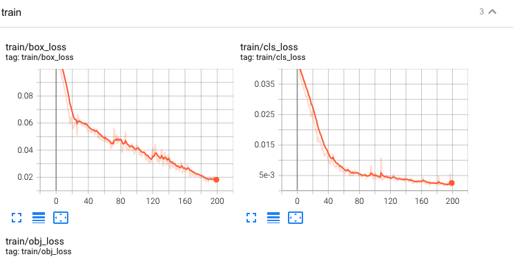

```python
!python detect.py --weights runs/train/exp/weights/best.pt --img 416 --conf 0.1 --source {dataset.location}/test/images
```

```
detect: weights=['runs/train/exp/weights/best.pt'], source=/content/datasets/Tennis-1/test/images, imgsz=[416, 416], conf_thres=0.1, iou_thres=0.45, max_det=1000, device=, view_img=False, save_txt=False, save_conf=False, save_crop=False, nosave=False, classes=None, agnostic_nms=False, augment=False,…
YOLOv5 🚀 v6.0-104-g4ca4aec torch 1.10.0+cu111 CUDA:0 (Tesla K80, 11441MiB)

Fusing layers...
Model Summary: 213 layers, 7018216 parameters, 0 gradients, 15.8 GFLOPs
image 1/5 /content/datasets/Tennis-1/test/images/download--6-_jpeg.rf.18c11acbf1e2ae8ada36dff4b2ee9ca5.jpg: 416x416 1 ball, 1 racket, Done. (0.028s)
image 2/5 /content/datasets/Tennis-1/test/images/download--8-_jpeg.rf.132e490bae4ce9cc53991f0d754328d2.jpg: 416x416 Done. (0.028s)
image 3/5 /content/datasets/Tennis-1/test/images/images--14-_jpeg.rf.0b35443141c6056ad8afcce876a83dcc.jpg: 416x416 1 racket, Done. (0.028s)
image 4/5 /content/datasets/Tennis-1/test/images/images--2-_jpeg.rf.3a378637b5d2ede92576db0fa7d430e6.jpg: 416x416 1 ball, 1 racket, Done. (0.028s)
image 5/5 /content/datasets/Tennis-1/test/images/images_jpeg.rf.c5d8d4316b8e7dadccf4708537130da2.jpg: 416x416 1 ball, 1 racket, 1 roger, Done. (0.028s)
Speed: 0.4ms pre-process, 28.3ms inference, 1.2ms NMS per image at shape (1, 3, 416, 416)
Results saved to runs/detect/exp
```

## Running AI model on some unseen held-out test images

[figure not shown]

[figure not shown]

[figure not shown]

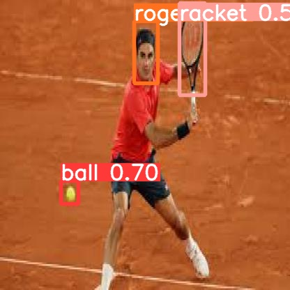

[figure not shown]

```python
import glob
from IPython.display import Image, display

for imageName in glob.glob('/content/yolov5/runs/detect/exp/*.jpg'): #assuming JPG
    display(Image(filename=imageName))
    print("\n")
```

```python
#exported my model's weights for future use
from google.colab import files
files.download('./runs/train/exp/weights/best.pt')
```

The fact that my model did so well inspite of tiny images making object detection hard(just like human eye finds it hard to detect objects if image is tiny, same intuition applies for my AI model), inspite of just 17 images (real world datasets are trained on atleast 250 images of each type), indicates that there is lot of room for improvement. I am confident I can better this performance  
---------------------------------------END-------------------------------------